# Gestion de fichier XML

## Expression du besoin

De nombreuses applications ont un besoin d’un format standard pour échanger et distribuer des données. Le langage **XML** répond à ses besoins et il s’est imposé comme **format de référence** pour l’échange de données.

## XML

XML signifie *eXtensible Markup Language* (Langage de balisage extensible).

Le langage est standardisé par la spécification W3C XML 1.0 du 10/02/98.

Lien : [cours XML](http://tvaira.free.fr/web/coursXML.pdf)

Un document XML **bien formé** signifie que le texte XML obéit aux règles syntaxiques de XML. Le document considéré comme **valide** (facultatif) signifie que le texte XML est bien formé et répond à une structure définie par une DTD (*Definition Type Document*).

*Remarque :* XML n’est pas un langage de programmation mais de description de document.

Les avantages d’XML sont nombreux :

- Lisibilité : aucune connaissance ne doit théoriquement être nécessaire pour comprendre un contenu d’un document XML (il est autodescriptif et extensible)
- Adaptabilité : sa structure arborescente permet de modéliser la majorité des problèmes informatiques
- Universalité et portabilité : fichier texte ASCII avec le support de l’encodage UNICODE
- Déployable : facilement distribué par n’importe quels protocoles capables de transporter du texte (comme HTTP)
- Exensibilité : ce métalangage le rend utilisable dans tous les domaines d’applications

Un document XML est structuré en trois parties :

- un **prologue** : qui indique la version XML utilisée, le jeu de caractères (*encoding*) et la présence d’une DTD (*standalone*).
- des **instructions** de traitement (IT) ou “*processing instruction*” (PI) : instructions relatives à des applications qui traiteront le document (feuille de style, transformation, …)
- l’**arbre des éléments** : le contenu du document

*Remarque :* par ailleurs, une feuille XML peut contenir des commentaires de la même manière qu’un document HTML.

Un document XML est composé d’**éléments** désignés par des **balises** et structuré sous la forme d’un **arbre** avec un et un seul élément **racine** (*root*).

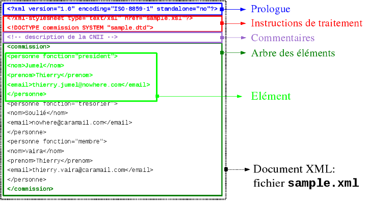

*Remarque :* Les éléments sont aussi appelés **noeuds** ou *nodes* (par référence à la théorie des graphes).

Un prologue contient systématiquement une déclaration qui spécifie la version de XML utilisée : `<?xml version="1.0" ?>`. Il existe également deux autres attributs : *encoding* (pour définir le type de codage du jeu de caractères) et *standalone* (pour préciser si une DTD est utilisée avec *no*).

De plus en plus de logiciels utilisent le format **XML** (*Extensible Markup Language*) pour leurs fichiers de données (Microsoft Office, LibreOffice/OpenOffice, …).

*Remarque :* ils existent pour l’échange de données des formats anciennement répandus comme le format CSV (voir l’activité sur les fichiers CSV) et les fichiers INI (voir l’activité sur les fichiers INI).

## API Qt

Qt fournit un module `QtXml` qu’il faut activer dans son fichier de projet `.pro` :

```
...
QT += xml
...
```

Dans ce module, Qt fournit de nombreuses classes qui permettent de gérer des documents **XML** :

- [Les classes du module QtXml en Qt4 (en)](http://doc.qt.io/qt-4.8/qtxml-module.html)
- [Les classes du module QtXml en Qt5 (en)](http://doc.qt.io/qt-5/qtxml-module.html)
- [Tutoriel Qt4 et le XML (fr)](http://qt.developpez.com/tutoriels/xml/)
- [Tutoriel Bien utiliser QtXml (fr)](http://qt.developpez.com/tutoriels/qtxml/)

La classe de base modélisant un document XML est `QDomDocument` :

- [La classe QDomDocument en Qt4 (en)](http://doc.qt.io/qt-4.8/qdomdocument.html)
- [La classe QDomDocument en Qt5 (en)](http://doc.qt.io/qt-5/qdomdocument.html)

# Objectifs

Être capable de lire et écrire des données dans un fichier XML.

## Séquence 1 : lire un fichier XML

On va créer une application GUI qui permet de gérer une liste d’interfaces USB. La description de ces interfaces est stockée dans le fichier `interfaces.xml` qui est lu au démarrage de l’application et afficher dans une liste déroulante. On pourra supprimer une interface ou ajouter une interface et le fichier XML sera mis à jour.

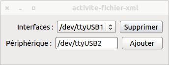

Le fichier `interfaces.xml` est le suivant :

```xml
<?xml version="1.0" encoding="UTF-8"?>
<interfaces>
  <interface id="0">
    <peripherique>/dev/ttyUSB0</peripherique>
  </interface>
  <interface id="1">
    <peripherique>/dev/ttyUSB1</peripherique>
  </interface>
</interfaces>
```

Pour manipuler ces interfaces dans le programme, on définira cette structure de données :

```cpp
typedef struct
{
    int      id;
    QString  peripherique;

} Interface;
```

La première tâche est de lire un fichier XML lorsqu’on démarre l’application afin d’afficher les interfaces disponibles dans la liste déroulante.

On vous fournit la méthode `lireXML()` qu’il vous faudra tester :

```cpp
bool MaFenetre::lireXML()
{
    // Le fichier XML
    QFile fichierXML(INTERFACES_XML);

    if(!(fichierXML.open(QIODevice::ReadOnly)))
    {
        QMessageBox::critical(0,"Erreur","Le fichier XML n'a pas pu être ouvert !");
        return false;
    }
    else
    {
        QDomDocument documentXML;

        documentXML.setContent(&fichierXML, false);
        QDomElement racine = documentXML.documentElement(); // <interfaces>
        if(racine.isNull())
        {
            qDebug() << "<MaFenetre::lireXML()> erreur racine !";
            return false;
        }

        QDomNode noeudInterface = racine.firstChild();
        if(noeudInterface.isNull())
        {
            qDebug() << "<MaFenetre::lireXML()> erreur racine vide !";
            return false;
        }

        while(!noeudInterface.isNull())
        {
            Interface interface;
            QDomElement elementInterface = noeudInterface.toElement(); // <interface>
            if(elementInterface.isNull())
            {
                qDebug() << "<MaFenetre::lireXML()> erreur element interface !";
                break;
            }

            QDomNode noeudPeripherique = elementInterface.firstChild();
            if(!noeudPeripherique.isNull())
            {
                QDomElement elementPeripherique = noeudPeripherique.toElement(); // <peripherique>

                interface.id = elementInterface.attribute("id").toInt(); // l'id
                interface.peripherique = elementPeripherique.text(); // le device
                interfaces.push_back(interface);
            }
            else qDebug() << "<MaFenetre::lireXML()> erreur noeud peripherique !";

            noeudInterface = noeudInterface.nextSibling();
        }

        fichierXML.close();
    }

    return true;
}
```

**Code source fourni :** activite-fichier-xml.zip

1. Tester l’application fournie avec les fichiers de test XML et identifier les erreurs.

## Séquence 2 : écrire dans un fichier XML

2. Implémenter l’écriture dans le fichier XML lorsqu’on supprime une interface ou qu’on en ajoute une dans la liste.
1. compléter le *slot* `supprimer()` qui doit supprimer un élément de la liste et actualiser l’affichage de la liste déroulante
2. compléter le *slot* `ajouter()` qui doit ajouter une interface dans la liste et actualiser l’affichage de la liste déroulante
3. écrire la méthode `ecrireXML()` et tester.

## Séquence 3 : valider un document XML

3. Vérifier si le document interfaces-dtd.xml est « valide » en utilisant tout d’abord un outil local (`xmllint`, `nsgmls` ou `rxp`) puis un outil distant (http://validator.w3.org/check ou voir les URLs fournis dans le cours). Faire différents tests.

Exemple si on oublie l’attribut `id` dans un élément `interface` :

```
$ xmllint -valid interfaces-dtd.xml
interfaces-dtd.xml:6: element interface: validity error :
Element interface does not carry attribute id
...
```

Avec la DTD suivante :

```
<!ELEMENT interfaces (interface+)>
<!ELEMENT interface (peripherique)>
<!ATTLIST interface id CDATA #REQUIRED>
<!ELEMENT peripherique (#PCDATA)>
```

Retour au sommaire